# TP : Méthodes d’optimisation

UE STA103

Robin Genuer

Février 2022

# 1 Introduction

L’objectif principal de notre partie du cours est de déterminer des maximums (ou des minimums) de fonctions. Pour ce faire, la méthode générale est de calculer la dérivée d’une fonction (ou plus généralement son gradient) puis de trouver le point annulant cette dérivée.

Dans les cas que nous avons rencontrés, nous étions en mesure de faire les calculs de façon exacte. Cependant, il est parfois impossible de mener ces calculs. Dans ces cas-là, on fait alors appel à des méthodes numériques, qui permettent de trouver des valeurs approchées du résultat. Dans ce TP, nous introduisons différentes méthodes numériques d’optimisation.

# 2 Méthode de la dichotomie

## 2.1 Description de la méthode

Soit $h: \mathbb{R} \longrightarrow \mathbb{R}$ une fonction continue qui ne s’annule qu’une seule fois sur $\mathbb{R}$ : il n’existe qu’un $x_0\in\mathbb{R}$ tel que $h(x_0)=0$. On suppose que $x_0$ est inconnu et impossible à déterminer de manière exacte.

Nous considérons une méthode permettant d’approcher $x_0$ : la méthode de dichotomie. Le principe général est le suivant :

- Partons de 2 points $a_0$ et $b_0$ tels que $a_0 < b_0$ et $h(a_0)h(b_0)<0$ (c’est-à-dire $h(a_0)$ et $h(b_0)$ sont de signes opposés et que donc $x_0$ est situé entre $a_0$ et $b_0$).
- On calcule alors $m_0$ le milieu du segment $[a_0,b_0]$ : $m_0=\frac{a_0+b_0}{2}$. L’idée est ensuite de déterminer où se trouve le zéro de la fonction parmi les deux segments suivants : $[a_0,m_0]$ et $[m_0,b_0]$.
- Ensuite on recommence avec le segment que l’on a choisi à l’étape précédente, que l’on note $[a_1, b_1]$. Donc on calcule $m_1=\frac{a_1+b_1}{2}$, etc.
- Et ainsi de suite…

## 2.2 Questions

1. Ecrire une fonction, appelée `dicho()` qui, étant donnée une fonction $h$ et 2 points initiaux $a_0$ et $b_0$ calcule une valeur approchée de $x_0$ à $\varepsilon$ près. De plus, cette fonction doit renvoyer le nombre d’itérations qui a permis d’obtenir l’approximation de $x_0$.

```r
dicho <- function(h, a0, b0, eps) {
    if (h(a0) * h(b0) > 0) {
        stop("x0 n'est pas dans l'intervalle [a0, b0]")
    } else {
        a <- a0
        b <- b0
        nb_iter <- 0

        while (abs(b - a) > eps & nb_iter < 1/eps) {
            m <- (a + b)/2
            if (h(a) * h(m) <= 0) {
                b <- m
            } else {
                a <- m
            }
            nb_iter <- nb_iter + 1
        }
    }
    return(list(x0 = m, nb_iter = nb_iter))
}
```

2. Tester cette fonction avec la fonction $h_{test}:x\mapsto x^3e^x + x -1$, $a_0 = -1$, $b_0=1$ et $\varepsilon=10^{-3}$. On vérifiera que l’image de la valeur approchée de $x_0$ par la fonction $h_{test}$ est bien proche de 0.

```r
h_test <- function(x) {
    x^3 * exp(x) + x - 1
}

dicho_test <- dicho(h = h_test, a0 = -1, b0 = 1, eps = 0.001)
dicho_test
```

```
## $x0
## [1] 0.6025391
##
## $nb_iter
## [1] 11
```

```r
h_test(dicho_test$x0)
```

```
## [1] 0.002147834
```

3. Vérifier graphiquement le résultat. Pour cela :
   - Construire un vecteur de valeurs entre -1 et 1, espacées de 0.001 les unes des autres (on pourra utiliser la fonction `seq()`).
   - Tracer la courbe représentative de la fonction $h_{test}$ entre -1 et 1, à l’aide de la fonction `plot()`.
   - Ajouter au graphique une droite verticale d’abscisse la valeur approchée de $x_0$ trouvée précédemment, puis une droite horizontale d’ordonnée $0$, à l’aide de la fonction `abline()`.

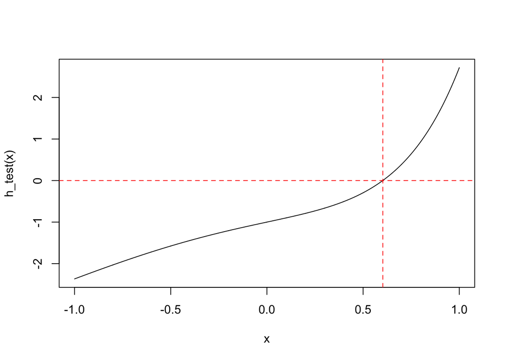

```r
vec <- seq(from = -1, to = 1, by = 0.001)
plot(vec, h_test(vec), type = "l", xlab = "x", ylab = "h_test(x)")
abline(h = 0, col = "red", lty = "dashed")
abline(v = dicho_test$x0, col = "red", lty = "dashed")
```

# 3 Méthode de Newton-Raphson

## 3.1 Description de la méthode

Plaçons-nous dans le cadre suivant : on considère $h: \mathbb{R} \longrightarrow \mathbb{R}$ une fonction deux fois dérivable sur $\mathbb{R}$ (sa dérivée seconde existe en tout point de $\mathbb{R}$), dont on veut déterminer le minimum. On suppose que ce minimum existe et qu’il est unique, c’est-à-dire qu’il n’existe qu’un $x_{min}\in\mathbb{R}$ tel que $x_{min} = \underset{\mathbb{R}}{\mathrm{argmin} \,} h$. On suppose que $x_{min}$ est inconnu et impossible à déterminer de manière exacte et on va donc en chercher une valeur approchée.

Introduisons maintenant la méthode de Newton-Raphson permettant d’approcher l’unique zéro d’une fonction $f$ dérivable sur $\mathbb{R}$, noté $x_0$ (c’est-à-dire que $x_0$ vérifie $f(x_0) = 0$) :

- Partons d’un point $z_0 \in \mathbb{R}$.
- Calculons $z_1 = z_0 - \frac{f(z_0)}{f'(z_0)}$.
- Ensuite, on recommence avec $z_2 = z_1 - \frac{f(z_1)}{f'(z_1)}$.
- Et ainsi de suite…

Après plusieurs étapes, on récupère une valeur approchée de $x_0$.

## 3.2 Questions

4. Expliquer comment procéder pour déterminer une valeur approchée de $x_{min}$, en utilisant la méthode de Newton.

**La méthode de Newton permet d’approcher le zéro d’une fonction. Si on veut l’utiliser pour déterminer un minimum, il faut donc l’appliquer à la dérivée de la fonction (et non à la fonction elle-même).**

5. Tout au long de l’exercice, nous allons prendre comme exemple la fonction suivante :

   $$h_{test}: x \longmapsto (x-1)^4 + x^2 + 4$$
   1. Donner l’équation que doit vérifier $x_{min}$, le minimum de cette fonction (donner juste l’équation, sans essayer de la résoudre).

      **L’équation que doit vérifier x_min est la suivante :**
      $$4(x_{min} -1)^3 + 2 x_{min} = 0$$
   2. Justifier le fait que le $x_{min}$ qui vérifie l’équation précédente est effectivement le minimum de la fonction $h_{test}: x \longmapsto (x-1)^4 + x^2 + 4$ (et non un maximum).

      **La dérivée seconde est strictement positive quelque soit $x$, donc on a bien un minium :**

      $$12(x-1)^2 + 2 > 0 \; \forall x \in \mathbb{R}$$
6. Ecrire une fonction R, appelée `newton()` qui, étant donné une fonction $f$, sa dérivée $f'$ et une valeur initiale $z_0$, calcule une valeur approchée de $x_0$ (le zéro de la fonction $f$) à $\varepsilon$ près.

```r
newton <- function(f, fprime, z0, eps) {
    x0 <- z0
    ecart <- eps + 1  # Il faut trouver une initialisation dont on est sûr qu'elle passe le test de la boucle while

    while (ecart > eps) {
        x0_ancien <- x0
        x0 <- x0_ancien - f(x0_ancien)/fprime(x0_ancien)
        ecart <- abs(x0 - x0_ancien)
    }

    return(x0)
}
```

7. Utiliser la fonction `newton()` pour trouver une valeur approchée du zéro de la fonction $f_{test}:x \longmapsto x^3 e^x + x -1$, $z_0 = 1$ et $\varepsilon=10^{-3}$. Puis comparer votre résultat avec celui obtenu grâce à la méthode de la dichotomie.

```r
f_test <- function(x) {
    x^3 * exp(x) + x - 1
}
fprime_test <- function(x) {
    (3 * x^2 + x^3) * exp(x) + 1
}

newton_test <- newton(f = f_test, fprime = fprime_test, z0 = 1, eps = 0.001)
newton_test
```

```
## [1] 0.6019047
```

```r
dicho <- function(h, a0, b0, eps) {
    if (h(a0) * h(b0) > 0) {
        stop("x0 n'est pas dans l'intervalle [a0, b0]")
    } else {
        a <- a0
        b <- b0
        nb_iter <- 0

        while (abs(b - a) > eps & nb_iter < 1/eps) {
            m <- (a + b)/2
            if (h(a) * h(m) <= 0) {
                b <- m
            } else {
                a <- m
            }
            nb_iter <- nb_iter + 1
        }
    }
    return(list(x0 = m, nb_iter = nb_iter))
}

dicho_ftest <- dicho(f_test, -1, 1, 0.001)
dicho_ftest$x0
```

```
## [1] 0.6025391
```

**Les deux résultats ne sont pas exactement égaux, mais sont très proches. Leur différence ne dépasse pas 0.001 (qui est la précision d’approximation utilisée pour les deux méthodes).**

8. Utiliser la fonction `newton()` pour trouver une valeur approchée du minimum de la fonction $h_{test}$ à $10^{-3}$ près. Faire une vérification graphique du résultat.

```r
htest <- function(x) {
    (x - 1)^4 + x^2 + 4
}
hprime_test <- function(x) {
    4 * (x - 1)^3 + 2 * x
}
hsec_test <- function(x) {
    12 * (x - 1)^2 + 2
}
```

**Ici, il faut faire attention à bien appliquer la fonction `newton()` à la dérivée et la dérivée seconde.**

```r
newton_htest <- newton(hprime_test, hsec_test, 1, 0.001)
newton_htest
```

```
## [1] 0.4102454
```

**Pour illustrer le fait, qu’on a bien trouvé un minimum, il est préférable de tracer la fonction (et non sa dérivée).**

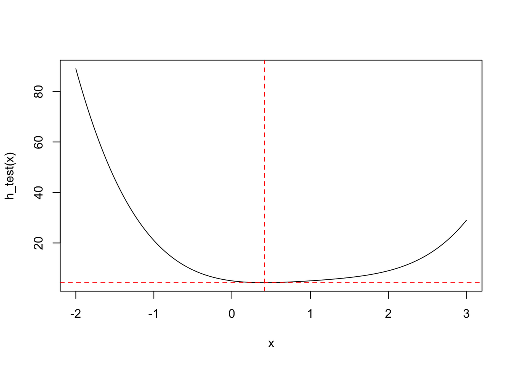

```r
x <- seq(-2, 3, by = 0.01)
plot(x, htest(x), type = "l", xlab = "x", ylab = "h_test(x)")
abline(v = newton_htest, col = "red", lty = "dashed")
abline(h = htest(newton_htest), col = "red", lty = "dashed")
```

9. Utiliser maintenant la fonction `dicho()` pour trouver une valeur approchée du minimum de la fonction $h_{test}$ à $10^{-3}$ près. Comparer le résultat à celui de la question précédente.

```r
dicho_htest <- dicho(hprime_test, -1, 1, 0.001)
dicho_htest$x0
```

```
## [1] 0.4111328
```

10. Modifier la fonction `newton()` pour qu’elle renvoie le nombre d’itérations qui a permis d’obtenir l’approximation de $x_0$.

```r
newton <- function(h, hprime, z0, eps) {
    nb_iter <- 0
    x0 <- z0
    ecart <- eps + 1

    while (ecart > eps & nb_iter < 1/eps) {
        x0_ancien <- x0
        x0 <- x0_ancien - h(x0_ancien)/hprime(x0_ancien)
        ecart <- abs(x0 - x0_ancien)
        nb_iter <- nb_iter + 1
    }

    return(list(x0 = x0, nb_iter = nb_iter))
}
```

11. Comparer le nombre d’itérations entre les deux méthodes (dichotomie et Newton) pour $\varepsilon \in \{10^{-3}, 10^{-4}, \ldots, 10^{-10} \}$ (*on ne calculera pas ces nombres d’itérations un par par un, mais de façon automatique avec R*) pour trouver le zéro de la fonction **$f_{test}$**, en prenant $z_0=1$ et $a_0=0$, $b_0=1$.

```r
comp_nb_iter <- matrix(NA, nrow = 8, ncol = 2)
for (i in 3:10) {
    comp_nb_iter[i - 2, 1] <- dicho(h = f_test, a0 = 0, b0 = 1, eps = 10^(-i))$nb_iter
    comp_nb_iter[i - 2, 2] <- newton(h = f_test, hprime = fprime_test, z0 = 1, eps = 10^(-i))$nb_iter
}

colnames(comp_nb_iter) <- c("dicho", "newton")
comp_nb_iter
```

```
##      dicho newton
## [1,]    10      5
## [2,]    14      5
## [3,]    17      5
## [4,]    20      6
## [5,]    24      6
## [6,]    27      6
## [7,]    30      6
## [8,]    34      7
```

**On pouvait aussi remplir deux vecteurs (plutôt qu’une matrice à 2 colonnes).**

**On observe que la méthode de newton() converge beaucoup plus vite que la méthode de dichotomie : elle a besoin d’un nombre d’itérations beaucoup plus faible que la dichotomie pour trouver une valeur approchée du zéro de la fonction.**

12. Comparer le nombre d’itérations entre les deux méthodes (dichotomie et Newton) pour $\varepsilon \in \{10^{-3}, 10^{-4}, \ldots, 10^{-10} \}$ (on ne calculera pas ces nombres d’itérations un par par un, mais de façon automatique avec R) pour trouver le minimum de la fonction **$h_{test}$**, en prenant $z_0=1$ et $a_0=0$, $b_0=1$.

```r
comp_nb_iter2 <- matrix(NA, nrow = 8, ncol = 2)
for (i in 3:10) {
    comp_nb_iter2[i - 2, 1] <- dicho(h = hprime_test, a0 = 0, b0 = 1, eps = 10^(-i))$nb_iter
    comp_nb_iter2[i - 2, 2] <- newton(h = hprime_test, hprime = hsec_test, z0 = 1,
        eps = 10^(-i))$nb_iter
}

colnames(comp_nb_iter2) <- c("dicho", "newton")
comp_nb_iter2
```

```
##      dicho newton
## [1,]    10      5
## [2,]    14      6
## [3,]    17      6
## [4,]    20      6
## [5,]    24      6
## [6,]    27      7
## [7,]    30      7
## [8,]    34      7
```

13. Considérons une nouvelle fonction :
    $$h_{test2} = (x-1)^4 + (x-2)^3 + 2 (x-2)^2$$
    En utilisant la fonction `newton()` avec $z_0 = 2$ et $\varepsilon = 10^{-3}$, donner une valeur approchée du minimum de la fonction $h_{test2}$. Appliquer de nouveau la fonction `newton()`, mais avec $z_0 = -0.5$ et $\varepsilon = 10^{-3}$ maintenant. Commenter. Tracer la courbe représentative de la fonction $h_{test2}$, puis expliquer les résultats obtenus avec ces deux valeurs de $z_0$.

```r
h_test2 <- function(x) {
    (x - 1)^4 + (x - 2)^3 + 2 * (x - 2)^2
}
hprime_test2 <- function(x) {
    4 * (x - 1)^3 + 3 * (x - 2)^2 + 4 * (x - 2)
}
hsec_test2 <- function(x) {
    12 * (x - 1)^2 + 6 * (x - 2) + 4
}
xmin2 <- newton(hprime_test2, hsec_test2, 2, 10^(-3))
xmin2
```

```
## $x0
## [1] 1.640388
##
## $nb_iter
## [1] 4
```

```r
xmin3 <- newton(hprime_test2, hsec_test2, -0.5, 10^(-3))
xmin3
```

```
## $x0
## [1] -9.677673e-09
##
## $nb_iter
## [1] 5
```

```r
h_test2(xmin2$x0)
```

```
## [1] 0.3803157
```

```r
h_test2(xmin3$x0)
```

```
## [1] 1
```

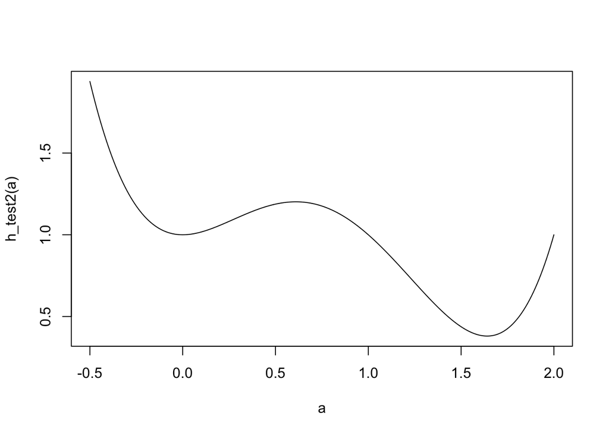

```r
a <- seq(-0.5, 2, by = 0.01)
plot(a, h_test2(a), type = "l")
```

**On voit qu’en fait, la fonction possède un minimum local et un minimum global. Et on remarque, qu’en fonction du point de départ (`z0`) de la fonction `newton()`, la méthode converge soit vers le minimum global, soit vers le minimum local. Il est donc important de garder en tête que ces méthodes d’approximation convergent (la plupart du temps) vers des minimums, mais dont on n’est pas sûr que ce soient des minimums globaux.**

14. Considérons maintenant une fonction de plusieurs variables : $F : \mathbb{R}^p \longmapsto \mathbb{R}$ pour $p\geq1$, différentiable en tout point de $\mathbb{R}^p$. On cherche maintenant $z_{min} = \underset{z \in \mathbb{R}^p}{\mathrm{argmin} \,} F(z)$. Ecrire la généralisation de la méthode de Newton-Raphson permettant de déterminer les optimums de fonctions de plusieurs variables.
- **Partons d’un point $z_0 \in \mathbb{R}^p$.**
- **Calculons $z_1 = z_0 - \left[ \nabla^2 F(z_0) \right]^{-1} \nabla F(z_0)$.**
- **Ensuite, on recommence avec $z_2 = z_1 - \left[ \nabla^2 F(z_1) \right]^{-1} \nabla F(z_1)$.**
- **Et ainsi de suite…**

# 4 Méthode de descente du gradient

## 4.1 Fonction d’une variable

### 4.1.1 Description de la méthode

Introduisons maintenant une méthode alternative aux méthodes de dichotomie et de Newton pour approcher l’unique minimum de la fonction $h$. Cette méthode est appelée méthode de descente de gradient et son principe général est le suivant :

- Partons d’un point $x_0 \in \mathbb{R}$.
- Calculons $x_1 = x_0 - s h'(x_0)$.
- Ensuite, on recommence avec $x_2 = x_1 - s h'(x_1)$.
- Et ainsi de suite…

$s$ est un paramètre réel positif et est appelé le **pas** de la descente

Après plusieurs étapes, on récupère une valeur approchée de $x_{min}$.

### 4.1.2 Questions

15. Tout au long de cette partie, nous allons prendre comme exemple la fonction suivante :
    $$h_{test}: x \longmapsto \frac{1}{4} x^4 +
    (x-1)^2$$
    1. Donner l’équation que doit vérifier $x_{min}$, le minimum de cette fonction (donner juste l’équation, sans essayer de la résoudre).

       **L’équation que doit vérifier $x_{min}$ est la suivante :**
       $$x_{min}^3 + 2 (x_{min} - 1) = 0$$
    2. Justifier le fait que le $x_{min}$ qui vérifie l’équation précédente est effectivement le minimum de la fonction $h_{test}$ (et non un maximum).

       **La dérivée seconde est strictement positive quelque soit $x$, donc on a bien un minium :**
       $$3 x^2 + 2 > 0 \; \forall x \in \mathbb{R}$$
16. Ecrire une fonction R, appelée `descente()` qui, étant donné une fonction dérivée $f'$, une valeur initiale $x_0$ et un pas $s$, calcule une valeur approchée de $x_{min}$ (le minimum de la fonction $f$) à $\varepsilon$ près.

```r
descente <- function(fprime, x0, s, eps) {
    x <- x0
    ecart <- eps + 1

    while (ecart > eps) {
        x_old <- x
        x <- x_old - s * fprime(x_old)
        ecart <- abs(x - x_old)
    }

    return(x)
}
```

17. Tester votre fonction `descente()` sur la fonction $h_{test}$ avec comme point de départ $x_0 = 0$, comme précision $\varepsilon = 10^{-5}$ et les valeurs suivantes pour le pas $s$ : $0.01, 0.1, 0.25, 0.5, 1$. Que remarquez-vous ?

```r
h_test <- function(x) {
    (x - 1)^2 + 1/4 * x^4
}
hprime_test <- function(x) {
    x^3 + 2 * (x - 1)
}

sval <- c(0.01, 0.1, 0.25, 0.5)
all_tests <- NULL
for (s in sval) {
    all_tests <- c(all_tests, descente(fprime = hprime_test, x0 = 0, s = s, eps = 1e-05))
}
all_tests
```

```
## [1] 0.7706648 0.7709060 0.7709170 0.7709124
```

**On remarque que toutes les valeurs approchées ne sont pas égales à $10^{-5}$ près. En effet, la valeur obtenue pour s = 0.01 est différente, donc prendre un pas trop petit peu avoir un effet néfaste.**

**La commande suivante :**

```r
test_s1 <- descente(fprime = hprime_test, x0 = 0, s = 1, eps = 1e-05)
```

**renvoie une erreur car l’algorithme diverge, donc prendre un pas trop grand peut carrément faire que la méthode ne fonctionne pas du tout. On peut le voir en exécutant les commandes de la boucle for plusieurs fois :**

```r
fprime <- hprime_test
x0 <- 1
s <- 1
x <- x0

x_old <- x
x <- x_old - s * fprime(x_old)
x
```

```
## [1] 0
```

```r
x_old <- x
x <- x_old - s * fprime(x_old)
x
```

```
## [1] 2
```

```r
x_old <- x
x <- x_old - s * fprime(x_old)
x
```

```
## [1] -8
```

```r
x_old <- x
x <- x_old - s * fprime(x_old)
x
```

```
## [1] 522
```

```r
x_old <- x
x <- x_old - s * fprime(x_old)
x
```

```
## [1] -142237168
```

```r
x_old <- x
x <- x_old - s * fprime(x_old)
x
```

```
## [1] 2.877659e+24
```

18. Modifier la fonction `descente()` pour qu’elle renvoie le nombre d’itérations qui a permis d’obtenir l’approximation de $x_{min}$.

```r
descente <- function(fprime, x0, s, eps) {
    nb_iter <- 0
    x <- x0
    ecart <- eps + 1

    while (ecart > eps & nb_iter < 1/eps) {
        x_old <- x
        x <- x_old - s * fprime(x_old)
        ecart <- abs(x - x_old)
        nb_iter <- nb_iter + 1
    }

    return(c(x, nb_iter))
}
```

19. Relancer les tests de la question 4 et comparer les nombres d’itérations pour les différentes valeurs de $s$ (sauf $s = 1$). Commenter.

```r
sval <- c(0.01, 0.1, 0.25, 0.5)
all_tests <- NULL
for (s in sval) {
    all_tests <- rbind(all_tests, descente(fprime = hprime_test, x0 = 0, s = s, eps = 1e-05))
}
res <- cbind(sval, all_tests)
colnames(res) <- c("sval", "x_min", "nb_iter")
res
```

```
##      sval     x_min nb_iter
## [1,] 0.01 0.7706648     221
## [2,] 0.10 0.7709060      25
## [3,] 0.25 0.7709170       7
## [4,] 0.50 0.7709124      94
```

## 4.2 Fonction de deux variables

Considérons maintenant une fonction de deux variables : $g : \mathbb{R}^2 \longmapsto \mathbb{R}$, différentiable en tout point de $\mathbb{R}^2$. On cherche maintenant $z_{min} = \underset{z \in \mathbb{R}^2}{\mathrm{argmin} \,} g(z)$.

### 4.2.1 Questions

20. La généralisation de la méthode de descente du gradient pour les fonctions de deux variables fonctionne exactement de la même façon que pour celle d’une variable (on se limitera au cas où le pas $s$ est le même pour toutes les directions, c’est-à-dire que même si le gradient est un vecteur, on ne prendra pas un vecteur de pas, mais bien une unique valeur pour le pas $s$). Ecrire cette généralisation en vous inspirant de la description de la partie précédente.

**Il suffit ici de recopier le principe de la partie 1, en remplaçant la dérivée par le gradient :**

- **Partons d’un point $z_0 \in \mathbb{R}^2$.**
- **Calculons $z_1 = z_0 - s \nabla g(z_0)$.**
- **Ensuite, on recommence avec $z_2 = z_1 - s \nabla g(z_1)$.**
- **Et ainsi de suite…**
21. Tout au long de cette partie, nous allons prendre comme exemple la fonction suivante :
    $$g_{test}: (x, y) \longmapsto \frac{1}{2} x^2 + \frac{7}{2} y^2 \enspace .$$
    Calculer le gradient de la fonction $g_{test}$.

$$\nabla g_{test} (x, y) = \begin{pmatrix}
x \\
7 y
\end{pmatrix}$$

22. Ecrire une fonction R, appelée `descente2()` qui, étant donné une fonction gradient $\nabla f$, une valeur initiale $z_0$ et un pas $s$, calcule une valeur approchée de $z_{min}$ (le minimum de la fonction $f$) à $\varepsilon$ près, et renvoie le nombre d’itérations (par “$\varepsilon$ près” il faut comprendre : la plus grande différence en valeur absolue dans les deux directions doit être inférieure à $\varepsilon$).

```r
descente2 <- function(nablaf, z0, s, eps) {
    nb_iter <- 0
    z <- z0
    ecart <- eps + 1

    while (ecart > eps & nb_iter < 1/eps) {
        z_old <- z
        z <- z_old - s * nablaf(z_old)
        ecart <- max(abs(z - z_old))
        nb_iter <- nb_iter + 1
    }

    return(c(z, nb_iter))
}
```

23. Tester votre fonction `descente2()` sur la fonction $g_{test}$ avec comme point de départ $(7, 1.5)$, comme précision $\varepsilon = 10^{-5}$ et les valeurs suivantes pour le pas $s$ : $0.01, 0.05, 0.125, 0.25, 0.325$. Commenter.

```r
g_test <- function(z) {
    1/2 * z[1]^2 + 7/2 * z[2]^2
}
nablag_test <- function(z) {
    c(z[1], 7 * z[2])
}

sval <- c(0.01, 0.05, 0.125, 0.25)
all_tests <- NULL
for (s in sval) {
    all_tests <- rbind(all_tests, descente2(nablaf = nablag_test, z0 = c(7, 1.5),
        s = s, eps = 1e-05))
}
result <- cbind(sval, all_tests)
colnames(result) <- c("sval", "z_min_1", "z_min_2", "nb_iter")
result
```

```
##       sval      z_min_1       z_min_2 nb_iter
## [1,] 0.010 9.893266e-04  2.388097e-28     882
## [2,] 0.050 1.898616e-04  6.657779e-39     205
## [3,] 0.125 6.306649e-05  4.048204e-79      87
## [4,] 0.250 1.670532e-05 -3.579712e-06      45
```

```r
# test_s1 <- descente2(nablaf = nablag_test, z0 = c(7, 1.5), s = 0.325, eps =
# 1e-5)
```

**Idem, une erreur ici.**

**On remarque des différences encore plus marquée entre les différentes valeurs approchées. Il faudrait penser à un autre critère pour la boucle while…**